# Check data

Ana Martinovici

Last compiled on 2021-06-09

```r
library("tidyverse")
load("recent_search/processed_data.RData")
```

# 1 Data descriptives

# 2 Location info in tweets

Let’s see which of the tweets, if any have location info. We have 4997 and 33 have location info.

```r
# tweets with location info
df_tweets %>% filter(geo_place_id != "no_geo_info") %>% select(text, geo_place_id)
```

```
## # A tibble: 33 x 2
##    text                                                          geo_place_id
##    <chr>                                                         <chr>
##  1 "“When will #BroodX go away so I can get back outside to pla~ aa509e938179ea~
##  2 "Sending you our love today \U0001f49e\U0001f43e\U0001f43e #~ 463f5d9615d7d1~
##  3 "She's been hiding all morning, came running downstairs to s~ 49fcf9322cd96b~
##  4 "Twins aged 15yrs. Oz (L) Jet (R) Rescued at 4 weeks old. Je~ 36a5570a0b9942~
##  5 "Graceful hunter. \U0001f923 #CatsOfTwitter https://t.co/baw~ 01a9a39529b27f~
##  6 "Morning nap after an intense play session #CatsOfTwitter #P~ 14441682ff5a9f~
##  7 "Tash's definition of heaven: no dogs, no Rufus. Balcony all~ f74cb9bd953a3c~
##  8 "I do love my hooman @Janetadavies1 but sometimes my nose ta~ 18e2a31ef383af~
##  9 "Good morning and happy Whisker Wednesday, from Sisko. #Cats~ 5a9de3ff3fdd84~
## 10 "Good morning and happy Whisker Wednesday, from Jadzia. #Cat~ 5a9de3ff3fdd84~
## # ... with 23 more rows
```

```r
# add the name of that location
df_tweets <- df_tweets %>% left_join(df_places, by = c("geo_place_id" = "place_id"))
df_tweets %>% filter(geo_place_id != "no_geo_info") %>% select(text, geo_place_id,
                                                               place_full_name,
                                                               place_name)
```

```
## # A tibble: 33 x 4
##    text                            geo_place_id   place_full_name     place_name
##    <chr>                           <chr>          <chr>               <chr>
##  1 "“When will #BroodX go away so~ aa509e938179e~ Annapolis, MD       Annapolis
##  2 "Sending you our love today \U~ 463f5d9615d7d~ Maine, USA          Maine
##  3 "She's been hiding all morning~ 49fcf9322cd96~ Featherstone, Engl~ Featherst~
##  4 "Twins aged 15yrs. Oz (L) Jet ~ 36a5570a0b994~ Holsworthy, England Holsworthy
##  5 "Graceful hunter. \U0001f923 #~ 01a9a39529b27~ Manhattan, NY       Manhattan
##  6 "Morning nap after an intense ~ 14441682ff5a9~ Sunrise, FL         Sunrise
##  7 "Tash's definition of heaven: ~ f74cb9bd953a3~ Oriental, Royaume ~ Oriental
##  8 "I do love my hooman @Janetada~ 18e2a31ef383a~ Berkhamsted, Engla~ Berkhamst~
##  9 "Good morning and happy Whiske~ 5a9de3ff3fdd8~ Santa Rosa, CA      Santa Rosa
## 10 "Good morning and happy Whiske~ 5a9de3ff3fdd8~ Santa Rosa, CA      Santa Rosa
## # ... with 23 more rows
```

```r
df_ref_tweets <- df_ref_tweets %>% left_join(df_places, by = c("ref_geo_place_id" = "place_id"))
df_ref_tweets %>%
    filter(ref_geo_place_id != "no_geo_info") %>%
    select(ref_text, ref_geo_place_id,
           place_full_name,
           place_name)
```

```
## # A tibble: 31 x 4
##    ref_text                       ref_geo_place_id place_full_name    place_name
##    <chr>                          <chr>            <chr>              <chr>
##  1 "Sending you our love today \~ 463f5d9615d7d1be Maine, USA         Maine
##  2 "Good morning and happy Whisk~ 5a9de3ff3fdd849d Santa Rosa, CA     Santa Rosa
##  3 "She's been hiding all mornin~ 49fcf9322cd96b9b Featherstone, Eng~ Featherst~
##  4 "Kitty standoff...wait for it~ 5a9de3ff3fdd849d Santa Rosa, CA     Santa Rosa
##  5 "Twins aged 15yrs. Oz (L) Jet~ 36a5570a0b9942a5 Holsworthy, Engla~ Holsworthy
##  6 "Tash's definition of heaven:~ f74cb9bd953a3c58 Oriental, Royaume~ Oriental
##  7 "I doez love a bit of washing~ 18e2a31ef383af36 Berkhamsted, Engl~ Berkhamst~
##  8 "Iz nesting M x #cats #CatsOf~ 18e2a31ef383af36 Berkhamsted, Engl~ Berkhamst~
##  9 "Nite nite all S x I hope you~ 18e2a31ef383af36 Berkhamsted, Engl~ Berkhamst~
## 10 "Good morning and happy Whisk~ 5a9de3ff3fdd849d Santa Rosa, CA     Santa Rosa
## # ... with 21 more rows
```

# 3 Length of tweet text

Adding the length of the tweet text and checking if there are differences between different types of tweets.

```r
df_tweets <- df_tweets %>% mutate(text_length = str_length(text))
df_tweets %>% group_by(tweet_type) %>% summarise(max_length = max(text_length))
```

```
## # A tibble: 4 x 2
##   tweet_type     max_length
##   <chr>               <int>
## 1 original_tweet        314
## 2 quoted                326
## 3 replied_to            202
## 4 retweeted             149
```

```r
df_ref_tweets <- df_ref_tweets %>% mutate(ref_text_length = str_length(ref_text))
df_tweets <- df_tweets %>%
    left_join(df_ref_tweets %>% select(ref_tweet_id, ref_text, ref_text_length),
              by = "ref_tweet_id")
df_tweets %>% group_by(tweet_type) %>% summarise(max_length = max(text_length),
                                                 max_ref_length = max(ref_text_length))
```

```
## # A tibble: 4 x 3
##   tweet_type     max_length max_ref_length
##   <chr>               <int>          <int>
## 1 original_tweet        314             NA
## 2 quoted                326            336
## 3 replied_to            202             NA
## 4 retweeted             149            326
```

```r
df_tweets %>%
    filter(tweet_type == "retweeted", ref_text_length > 150) %>%
    select(tweet_id, text, text_length, ref_tweet_id, ref_text, ref_text_length)
```

```
## # A tibble: 1,632 x 6
##    tweet_id  text        text_length ref_tweet_id  ref_text      ref_text_length
##    <chr>     <chr>             <int> <chr>         <chr>                   <int>
##  1 14026248~ "RT @Rowan~         139 140233495357~ "Two kittens~             294
##  2 14026248~ "RT @Rowan~         139 140233495357~ "Two kittens~             294
##  3 14026248~ "RT @Rowan~         139 140233495357~ "Two kittens~             294
##  4 14026248~ "RT @Rowan~         139 140233495357~ "Two kittens~             294
##  5 14026248~ "RT @Rowan~         139 140233495357~ "Two kittens~             294
##  6 14026248~ "RT @Rowan~         139 140233495357~ "Two kittens~             294
##  7 14026248~ "RT @Rowan~         139 140233495357~ "Two kittens~             294
##  8 14026247~ "RT @Mommy~         139 140262476740~ "Shrimp came~             227
##  9 14026247~ "RT @Cat_K~         144 140231913504~ "\U0001f431#~             302
## 10 14026247~ "RT @Cat_K~         144 140231913504~ "\U0001f431#~             302
## # ... with 1,622 more rows
```

The **text** in **df_tweets** is truncated for retweets. If you want to use the full text of the tweet that was retweeted, then you need to use **ref_text**.

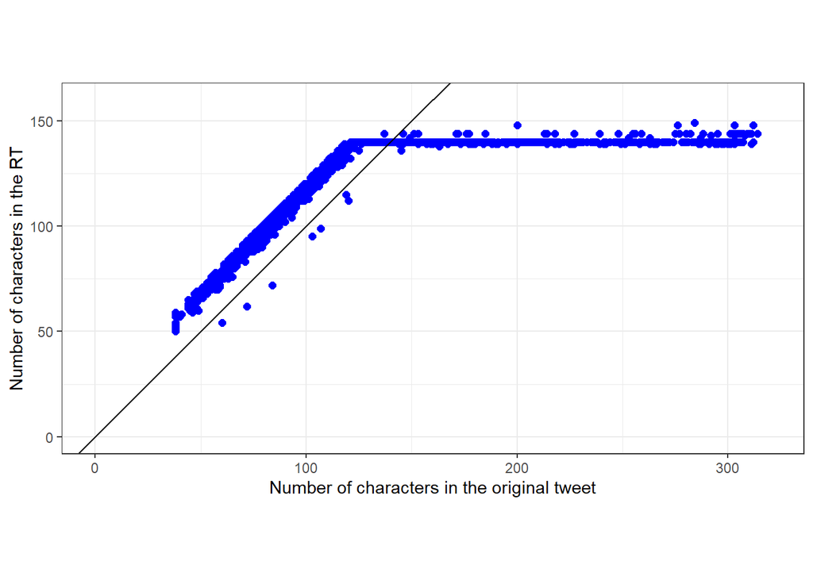

```r
df_tweets %>%
    filter(tweet_type == "retweeted") %>%
    ggplot(aes(x = ref_text_length, y = text_length)) +
    geom_point(col = "blue", size = 2) +
    geom_abline(intercept = 0, slope = 1) +
    theme_bw() +
    xlab(label = "Number of characters in the original tweet") +
    ylab(label = "Number of characters in the RT") +
    scale_x_continuous(limits = c(0, 320)) +
    scale_y_continuous(limits = c(0, 160)) +
    coord_fixed(ratio = 1)
```

# 4 Public metrics

## 4.1 Retweet count

Adding metrics of referenced tweets.

```r
df_tweets <- df_tweets %>%
    left_join(df_ref_tweets %>% select(ref_tweet_id,
                                       ref_retweet_count, ref_reply_count,
                                       ref_like_count, ref_quote_count),
              by = "ref_tweet_id")
```

Let **Tweet 1** be the id of an “original tweet”. Then, if this original tweet gets retweeted, the let the id of the RT be **Tweet 2**. The retweet count associated with **Tweet 2** is the same as that associated with **Tweet 1**. The figure below show this for our sample:

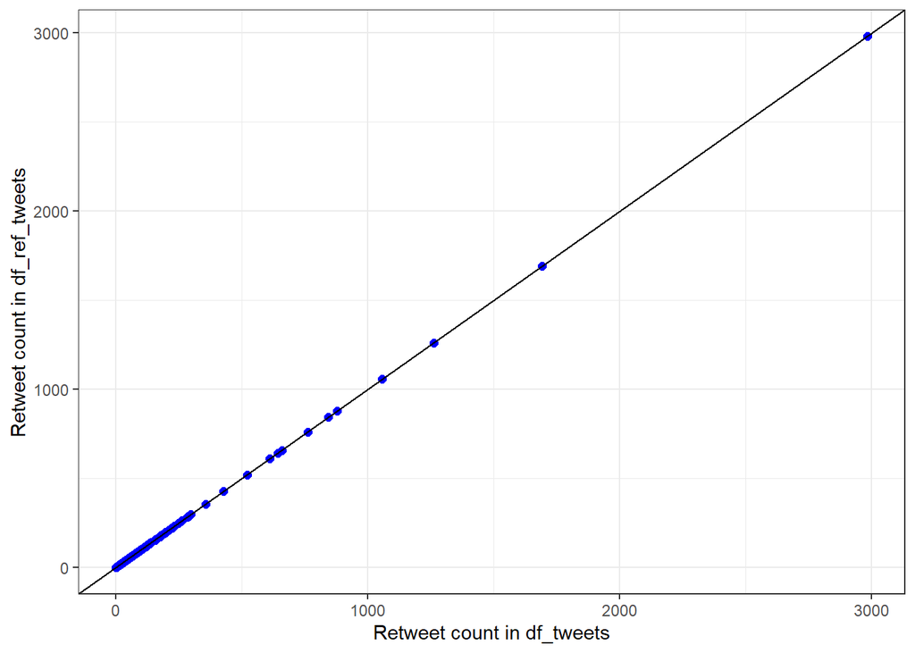

```r
df_tweets %>%
    filter(tweet_type == "retweeted") %>%
    ggplot(aes(x = retweet_count, y = ref_retweet_count)) +
    geom_point(size = 2, col = "blue") +
    geom_abline(intercept = 0, slope = 1) +
    theme_bw() +
    xlab(label = "Retweet count in df_tweets") +
    ylab(label = "Retweet count in df_ref_tweets")
```

This is different for quoted tweets. Let **Tweet 3** be a quoted tweet, starting from **Tweet 1**. Then, the retweet count associated with **Tweet 3** gives the number of times that **Tweet 3** was retweeted.

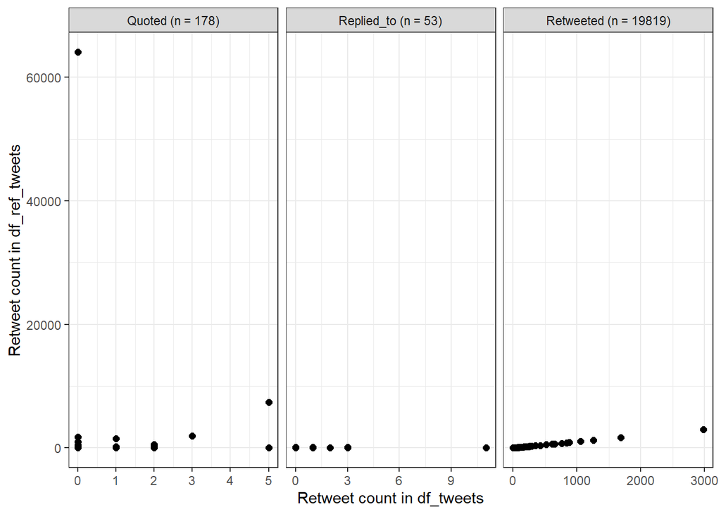

```r
df_labels <- c("replied_to" = paste("Replied_to (n = ",
                                    nrow(df_tweets %>% filter(tweet_type %in% c("replied_to"))), ")", sep = ""),
               "quoted" = paste("Quoted (n = ",
                                nrow(df_tweets %>% filter(tweet_type %in% c("quoted"))), ")", sep = ""),
               "retweeted" = paste("Retweeted (n = ",
                                   nrow(df_tweets %>% filter(tweet_type %in% c("retweeted"))), ")", sep = ""))

df_tweets %>%
    filter(tweet_type %in% c("replied_to", "quoted", "retweeted")) %>%
    ggplot(aes(x = retweet_count, y = ref_retweet_count)) +
    geom_point(size = 2) +
    facet_grid(cols = vars(tweet_type),
               scales = "free",
               labeller = labeller(tweet_type = df_labels)) +
    theme_bw() +
    xlab(label = "Retweet count in df_tweets") +
    ylab(label = "Retweet count in df_ref_tweets")
```

## 4.2 Quote retweets

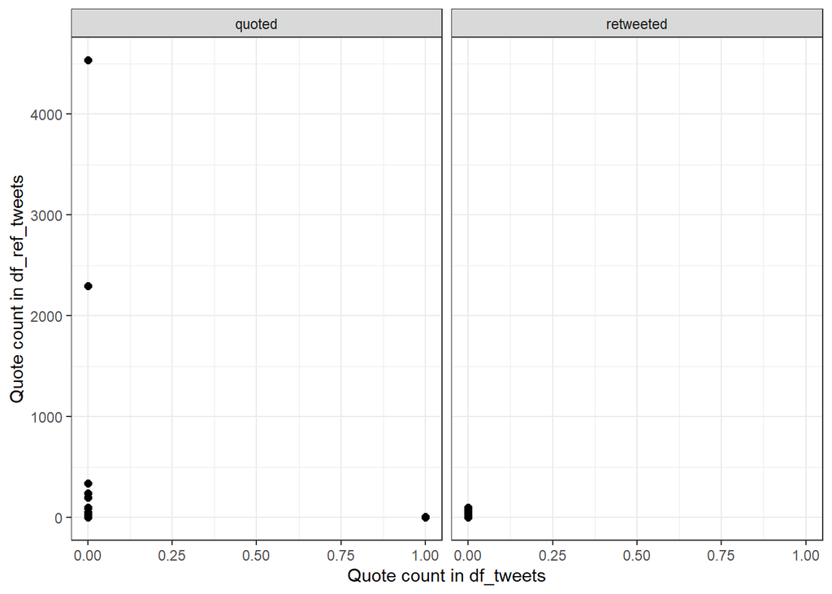

```r
df_tweets %>%
    filter(tweet_type %in% c("quoted", "retweeted")) %>%
    ggplot(aes(x = quote_count, y = ref_quote_count)) +
    geom_point(size = 2) +
    facet_wrap(vars(tweet_type)) +
    theme_bw() +
    xlab(label = "Quote count in df_tweets") +
    ylab(label = "Quote count in df_ref_tweets")
```

## 4.3 Likes

Looks like tweets that are retweeted also get quite a few likes. And those likes count towards the original tweet.

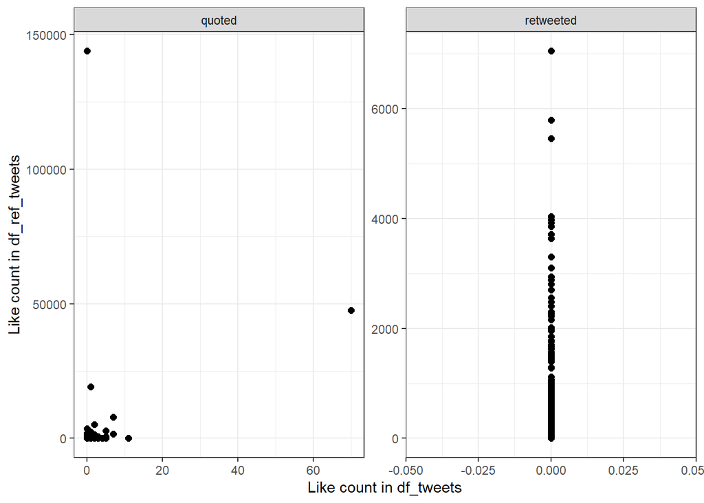

```r
df_tweets %>%
    filter(tweet_type %in% c("quoted", "retweeted")) %>%
    ggplot(aes(x = like_count, y = ref_like_count)) +
    geom_point(size = 2) +
    facet_wrap(vars(tweet_type),
               scales = "free") +
    theme_bw() +
    xlab(label = "Like count in df_tweets") +
    ylab(label = "Like count in df_ref_tweets")
```

## 4.4 Replies

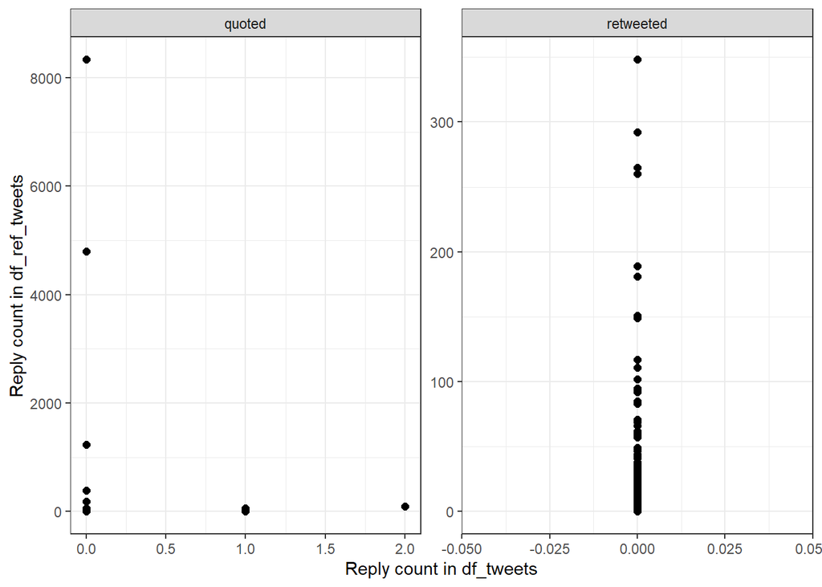

```r
df_tweets %>%
    filter(tweet_type %in% c("quoted", "retweeted")) %>%
    ggplot(aes(x = reply_count, y = ref_reply_count)) +
    geom_point(size = 2) +
    facet_wrap(vars(tweet_type),
               scales = "free") +
    theme_bw() +
    xlab(label = "Reply count in df_tweets") +
    ylab(label = "Reply count in df_ref_tweets")
```